# ST308 - week 02

In this workshop:

- Basic commands for vectors and matrices
- Data visualisation
- Loading data

## Basic R Commands

**Vectors and sequences**

- Create vectors x and y
- Vector arithmetic

```r
x <- c(1,3,2,5)
y <-  c(1,4,3,0)

length(x)
```

```
## [1] 4
```

```r
length(y)
```

```
## [1] 4
```

```r
x+y
```

```
## [1] 2 7 5 5
```

```r
2*x-y+1
```

```
## [1]  2  3  2 11
```

The function `seq` creates a sequence of numbers

```r
#sequences
x <- seq(1,10)

#sequence with specified number of values
y <- seq(1,10,length.out=20)
```

`rm` is the function that removes objects from the environment

```r
rm(x,y)  #to remove objects x and y
#rm(list=ls())
```

**Matrices**

The function `matrix` creates a matrix object.

To construct a 2X2 matrix with numbers from 1 to 4, do:

```r
?matrix
x=matrix(data=c(1,2,3,4), nrow=2, ncol=2)
x
```

```
##      [,1] [,2]
## [1,]    1    3
## [2,]    2    4
```

```r
x=matrix(c(1,2,3,4),2,2)
```

**Elementwise operations on matrices**

To find the square root and the square of each matrix’s component:

```r
# Elementwise operations on matrices
sqrt(x)
```

```
##          [,1]     [,2]
## [1,] 1.000000 1.732051
## [2,] 1.414214 2.000000
```

```r
x^2
```

```
##      [,1] [,2]
## [1,]    1    9
## [2,]    4   16
```

## Indexing Data

Below are some commands for practicing in working with matrices and accessing their elements

```r
A=matrix(1:16,4,4)
A
```

```
##      [,1] [,2] [,3] [,4]
## [1,]    1    5    9   13
## [2,]    2    6   10   14
## [3,]    3    7   11   15
## [4,]    4    8   12   16
```

```r
A[2,3]
```

```
## [1] 10
```

```r
A[c(1,3),c(2,4)]
```

```
##      [,1] [,2]
## [1,]    5   13
## [2,]    7   15
```

```r
A[1:3,2:4]
```

```
##      [,1] [,2] [,3]
## [1,]    5    9   13
## [2,]    6   10   14
## [3,]    7   11   15
```

```r
A[1:2,]
```

```
##      [,1] [,2] [,3] [,4]
## [1,]    1    5    9   13
## [2,]    2    6   10   14
```

```r
A[,1:2]
```

```
##      [,1] [,2]
## [1,]    1    5
## [2,]    2    6
## [3,]    3    7
## [4,]    4    8
```

```r
A[1,]
```

```
## [1]  1  5  9 13
```

```r
A[-c(1,3),]
```

```
##      [,1] [,2] [,3] [,4]
## [1,]    2    6   10   14
## [2,]    4    8   12   16
```

```r
A[-c(1,3),-c(1,3,4)]
```

```
## [1] 6 8
```

```r
dim(A)
```

```
## [1] 4 4
```

## Drawing observations from normal distribution

```r
x=rnorm(50)

#for replicability set seed
set.seed(1303)
rnorm(50)
```

```
##  [1] -1.1439763145  1.3421293656  2.1853904757  0.5363925179  0.0631929665
##  [6]  0.5022344825 -0.0004167247  0.5658198405 -0.5725226890 -1.1102250073
## [11] -0.0486871234 -0.6956562176  0.8289174803  0.2066528551 -0.2356745091
## [16] -0.5563104914 -0.3647543571  0.8623550343 -0.6307715354  0.3136021252
## [21] -0.9314953177  0.8238676185  0.5233707021  0.7069214120  0.4202043256
## [26] -0.2690521547 -1.5103172999 -0.6902124766 -0.1434719524 -1.0135274099
## [31]  1.5732737361  0.0127465055  0.8726470499  0.4220661905 -0.0188157917
## [36]  2.6157489689 -0.6931401748 -0.2663217810 -0.7206364412  1.3677342065
## [41]  0.2640073322  0.6321868074 -1.3306509858  0.0268888182  1.0406363208
## [46]  1.3120237985 -0.0300020767 -0.2500257125  0.0234144857  1.6598706557
```

```r
set.seed(3)
y=rnorm(100)
mean(y)
```

```
## [1] 0.01103557
```

```r
var(y)
```

```
## [1] 0.7328675
```

```r
sqrt(var(y))
```

```
## [1] 0.8560768
```

```r
sd(y)
```

```
## [1] 0.8560768
```

**Correlations**

Recall the Pearson correlation measures the strength of linear relationshiop between 2 quantitative variables, and takes values [-1,1].

Task: Create 2 variables: 50 observations from $X \sim N(0,1)$, and $Y=X+N(50,0.1^2)$ Then compute the (Pearson’s) correlation.

```r
y=x+rnorm(50,mean=50,sd=.1)
cor(x,y)
```

```
## [1] 0.9954671
```

## Activity 1

1. Run the following chunk:

```r
A <- matrix(c(1,2,3,4),2,2,byrow=TRUE)
t(A)
```

```
##      [,1] [,2]
## [1,]    1    3
## [2,]    2    4
```

What does the function `t` do?

2. Draw 10 numbers from the normal distribution with mean 5 and variance 2. Store them in the vector x and calculate the sample mean and standard deviation. Put them in a 2 X 5 matrix by row and and raise each number to the power of three.

## Data visualisation

R has a set of functions for creating plots. A popular package for data visualisation is ggplot. We will focus on the core R graphics.

**Scatterplot**

1st simulate data for 2 variables and store values in a data frame object.

```r
x1 <- rnorm(100)
y1 <- rnorm(100)

dat <- data.frame(x1,y1)
dat
```

```
##              x1           y1
## 1   -1.29134932 -0.535063085
## 2    2.63504537  1.368106222
## 3    0.48707229  0.141844290
## 4    0.85389232 -0.782814969
## 5    1.08844271  1.881518733
## 6    0.22601396  0.552922865
## 7    0.06819884 -1.844856583
## 8   -0.98481553 -0.550307914
## 9   -1.31085442 -0.026014759
## 10   2.46405534 -2.159250362
## 11  -0.66542807  1.770600080
## 12   0.91286265  0.760473482
## 13   0.96466423 -0.484542846
## 14   1.60800294 -0.472763899
```

[output cut: 86 more lines]

`plot` produces a scatterplot

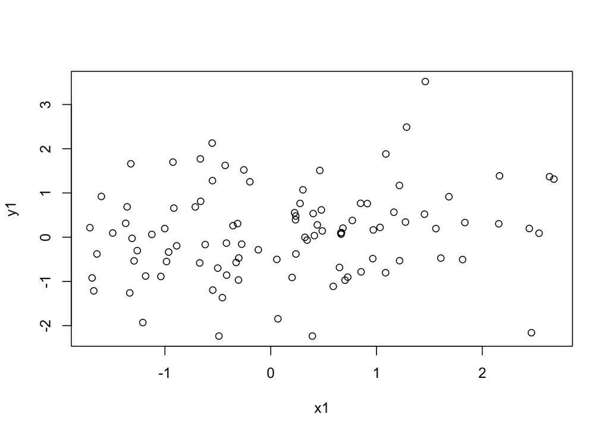

```r
plot(x1,y1) #note order matters
```

To save the plot as a pdf in your folder, do:

```r
pdf("Figure.pdf")
plot(x,y,col="blue")
dev.off()  #closes the plot and uploads it
```

## Loading Data

The functions for loading data depends on the format of the data.

- `read.table` is used to load data that is stored as a txt or csv file.
- `read.csv` is for csv

A common error when loading data is not checking whether or not the data comes with a header. Also, if you had not already done so at the beginning of your session, set the working directory to the folder where your files are stored.

**Example: Automobile data**

The data Auto.data.txt consists of variables on the profile of vehicles. The data set contains a header (check). Data sets may have variables with missing values. Here, `na.strings=?` sets anything with ? to NA.

Load the data and check all us ok using `head`:

```r
Auto <- read.table("Auto.txt", header=T,na.strings="?")
head(Auto)
```

```
##   mpg cylinders displacement horsepower weight acceleration year origin
## 1  18         8          307        130   3504         12.0   70      1
## 2  15         8          350        165   3693         11.5   70      1
## 3  18         8          318        150   3436         11.0   70      1
## 4  16         8          304        150   3433         12.0   70      1
## 5  17         8          302        140   3449         10.5   70      1
## 6  15         8          429        198   4341         10.0   70      1
##                        name
## 1 chevrolet chevelle malibu
## 2         buick skylark 320
## 3        plymouth satellite
## 4             amc rebel sst
## 5               ford torino
## 6          ford galaxie 500
```

`summary` gives the 5-point summary statistics plus the mean for each variable.

```r
summary(Auto)
```

```
##       mpg          cylinders      displacement     horsepower
##  Min.   : 9.00   Min.   :3.000   Min.   : 68.0   Min.   : 46.0
##  1st Qu.:17.50   1st Qu.:4.000   1st Qu.:104.0   1st Qu.: 75.0
##  Median :23.00   Median :4.000   Median :146.0   Median : 93.5
##  Mean   :23.52   Mean   :5.458   Mean   :193.5   Mean   :104.5
##  3rd Qu.:29.00   3rd Qu.:8.000   3rd Qu.:262.0   3rd Qu.:126.0
##  Max.   :46.60   Max.   :8.000   Max.   :455.0   Max.   :230.0
##                                                  NA's   :5
##      weight      acceleration        year           origin
##  Min.   :1613   Min.   : 8.00   Min.   :70.00   Min.   :1.000
##  1st Qu.:2223   1st Qu.:13.80   1st Qu.:73.00   1st Qu.:1.000
##  Median :2800   Median :15.50   Median :76.00   Median :1.000
##  Mean   :2970   Mean   :15.56   Mean   :75.99   Mean   :1.574
##  3rd Qu.:3609   3rd Qu.:17.10   3rd Qu.:79.00   3rd Qu.:2.000
##  Max.   :5140   Max.   :24.80   Max.   :82.00   Max.   :3.000
##
##              name
##  ford pinto    :  6
##  amc matador   :  5
##  ford maverick :  5
##  toyota corolla:  5
##  amc gremlin   :  4
##  amc hornet    :  4
##  (Other)       :368
```

**Subsetting data**

We can answer such question by using functions for subsetting the data. There is more than one way to subset data and it’s a matter of preference.

The number of vehicles is:

```r
nrow(subset(Auto,mpg>10)) #or use dim
```

```
## [1] 394
```

The histogram for mpg with horsepower =90 is:

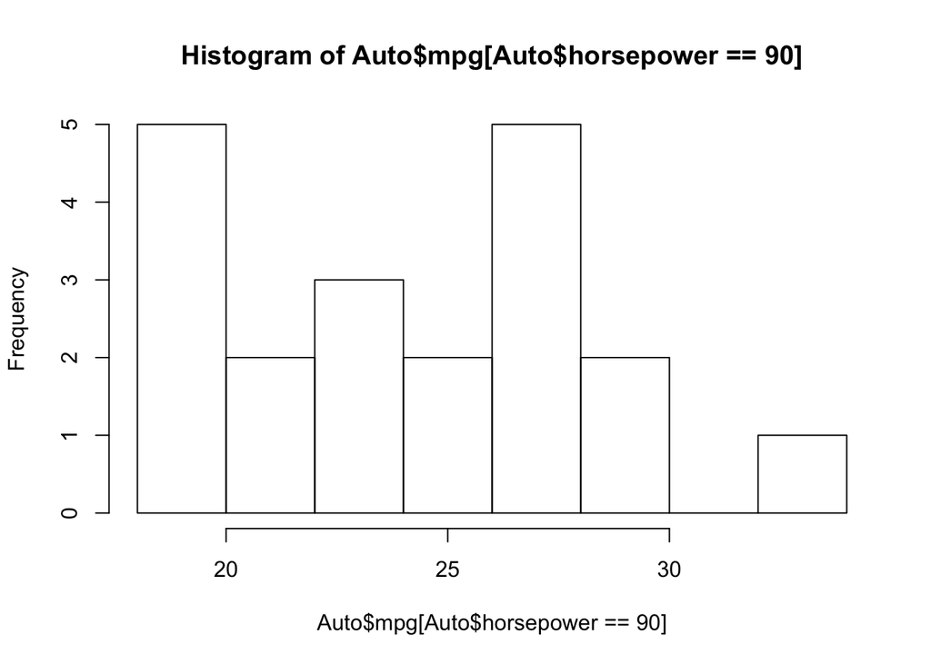

```r
hist(Auto$mpg[Auto$horsepower==90]) # note the double =
```

## Activity 2

This exercise involves the Boston housing data set which is part of the MASS library in R. You can read about it typing `?Boston` after loading the library. To load and view part of it use the following commands:

```r
library(MASS)
head(Boston)
```

```
##      crim zn indus chas   nox    rm  age    dis rad tax ptratio  black
## 1 0.00632 18  2.31    0 0.538 6.575 65.2 4.0900   1 296    15.3 396.90
## 2 0.02731  0  7.07    0 0.469 6.421 78.9 4.9671   2 242    17.8 396.90
## 3 0.02729  0  7.07    0 0.469 7.185 61.1 4.9671   2 242    17.8 392.83
## 4 0.03237  0  2.18    0 0.458 6.998 45.8 6.0622   3 222    18.7 394.63
## 5 0.06905  0  2.18    0 0.458 7.147 54.2 6.0622   3 222    18.7 396.90
## 6 0.02985  0  2.18    0 0.458 6.430 58.7 6.0622   3 222    18.7 394.12
##   lstat medv
## 1  4.98 24.0
## 2  9.14 21.6
## 3  4.03 34.7
## 4  2.94 33.4
## 5  5.33 36.2
## 6  5.21 28.7
```

1. How many rows are in this data set? How many columns? What do the rows and columns represent?
2. Are any of the predictors ‘age’, dis ‘ptratio’ appear to be associated with per capita crime rate? If so, explain the relationship.
3. In this data set, how many of the suburbs average more than seven rooms per dwelling? More than eight rooms per dwelling?

### Put your code below

Knit the file and check the output!